Coding Essentials for Astronomers

# Astroquery and Astropy: Units and Coordinates

## Introduction

For the past two lectures, you've been analyzing `gaia_dr3_rvs_sample.csv` - a catalog of 5000 nearby stars. You've grouped them by color, merged observation logs, computed statistics, and built sophisticated data analysis workflows.

But where did that CSV file come from? Did I manually download 5000 stars one by one from a website? Copy-paste coordinates into a spreadsheet?

**Of course not.** Astronomers work with millions of sources across thousands of catalogs. Manual data collection would be impossible. Instead, we use **programmatic queries** - writing code to search astronomical databases and retrieve exactly the data we need.

Today you'll learn how to query astronomical databases to get your own catalogs instead of relying on pre-made CSV files, how to work with data that has physical units attached rather than naked numbers that lose their meaning, how to understand celestial coordinates and transform between different systems, how to cross-match catalogs by position when they don't share a common ID, and how to compute 3D space velocities from measurements made on the 2D sky.

By the end of this lecture, you'll be able to access data from the world's astronomical archives, work with proper units that prevent errors, transform coordinates between systems, match catalogs spatially, and compute physical quantities like space velocities. These are essential skills for astronomical research.

Let's start by recreating that CSV file you've been using...

We'll start with our familiar tools and import astronomy-specific modules as we need them.

```python
import numpy as np
import pandas as pd
import matplotlib.pyplot as plt

# Set pandas display options
pd.set_option('display.max_columns', 20)
pd.set_option('display.width', 120)
pd.set_option('display.precision', 3)

# Plotting defaults
plt.rcParams['figure.figsize'] = (12, 8)
plt.rcParams['font.size'] = 12

print("Basic libraries loaded!")
```

```
Basic libraries loaded!
```

## Astroquery - Accessing Astronomical Databases

### The Problem: How Do Astronomers Get Data?

Modern astronomy generates enormous datasets. Gaia has measured positions and brightnesses for nearly 2 billion stars. The Sloan Digital Sky Survey (SDSS) has spectra for millions of galaxies. The Two Micron All Sky Survey (2MASS) has infrared photometry for 500 million sources. Hundreds of specialized catalogs exist for specific science goals - X-ray sources, variable stars, exoplanet hosts, and more.

You can't download entire databases. Gaia Data Release 3 is over 11 terabytes! Even if you had the storage, downloading everything would take weeks and you'd only use a tiny fraction. Instead, astronomical archives provide query interfaces where you describe what you want and they return just those data.

Different missions and surveys are operated by different space agencies and institutions around the world. NASA runs missions like Hubble and James Webb Space Telescope. The European Space Agency (ESA) runs Gaia. Ground-based surveys like SDSS and 2MASS have their own facilities. Remarkably, almost all astronomical data are made publicly available - an "open sky policy" where taxpayer-funded observations are shared with the global scientific community. This policy accelerates discovery by letting researchers combine data from multiple sources.

But each archive historically had its own query language, website interface, and data formats. Astroquery solves this by providing a unified Python interface to dozens of archives. Instead of learning each archive's quirks, you use consistent Python code for all of them.

### Our Goal: Recreate the Gaia Sample

The CSV file you've been using contains 5000 stars from Gaia Data Release 3, all within 100 parsecs of the Sun (relatively nearby on galactic scales), all with measured radial velocities showing their motion toward or away from us, and all bright enough to study easily. Let me show you the query that created it.

```python
# Import Gaia query module from astroquery package
from astroquery.gaia import Gaia
```

The `astroquery.gaia` module provides access to ESA's Gaia archive. After importing, we use `Gaia.launch_job()` or `Gaia.launch_job_async()` to send queries to the archive and retrieve results.

### Understanding ADQL: Astronomical Data Query Language

Gaia uses **ADQL (Astronomical Data Query Language)**, which is based on **SQL (Structured Query Language)**. SQL is a standard language used throughout industry and science for querying relational databases. ADQL extends SQL with astronomical-specific features like cone searches and cross-matches.

SQL allows the database engine to optimize queries using indexes and other techniques, making searches through massive datasets nearly instantaneous. We'll cover SQL more in later lectures, but the structure is intuitive even if you've never seen it.

A query has three main parts:

- `SELECT` tells you which columns you want
- `FROM` tells you which table to search
- `WHERE` specifies filtering conditions

In plain English, you're saying "Give me the source_id, position, and brightness of stars from the Gaia catalog where parallax is greater than 10 milliarcseconds."

Let's start with a simple query to understand the syntax before building complexity.

### Simple Query: Get 10 Nearby Bright Stars

Here's the simplest possible query - just get 10 stars and a few basic properties. Note that `SELECT TOP 10` gets the first 10 rows that match our criteria - it's not a random selection unless we add `ORDER BY random_index`.

```python
# A minimal Gaia query
simple_query = """
SELECT TOP 10
    source_id,
    ra, dec,
    parallax,
    phot_g_mean_mag
FROM gaiadr3.gaia_source
WHERE parallax > 10
"""

print("Sending query to Gaia archive...")
job = Gaia.launch_job(simple_query)
results = job.get_results()

print(f"Retrieved {len(results)} stars")
print(f"\nResult type: {type(results)}")
print("\nFirst few rows:")
results
```

```
Sending query to Gaia archive...
```

```
Retrieved 10 stars

Result type: <class 'astropy.table.table.Table'>

First few rows:
```

*Table length=10*

| source_id int64 | ra deg float64 | dec deg float64 | parallax mas float64 | phot_g_mean_mag mag float32 |
| --- | --- | --- | --- | --- |
| 4040303536728364032 | 268.9340025131472 | -36.78808327153041 | 10.000005410606198 | 20.043499 |
| 1769202380476257280 | 326.9649713590381 | 14.82578261853893 | 10.000008327879812 | 15.390248 |
| 5865060558925435136 | 203.82996968854363 | -63.345651497113174 | 10.000011521931214 | 20.534351 |
| 5991077025398967936 | 242.1197251797219 | -45.38613923262685 | 10.000018482890486 | 20.43332 |
| 6587959595560946560 | 327.374700930929 | -35.89820096056811 | 10.000019790652779 | 20.55112 |
| 518180210764160512 | 30.15544146978542 | 65.2666872222712 | 10.000029388163865 | 13.608475 |
| 473881441333817984 | 60.74761405694887 | 60.72733515983865 | 10.000031865768985 | 9.267752 |
| 4268948251011683200 | 286.48065890820794 | 3.0983673883767744 | 10.000033274917804 | 19.219837 |
| 4060338184761215872 | 264.0122743177974 | -28.606811608560882 | 10.000037332774403 | 20.232632 |
| 2629631149026173952 | 337.05247480726354 | -1.7618590288703149 | 10.000042091841326 | 16.122866 |

**What just happened?**

We wrote a query asking for the `TOP 10` rows (first 10 matches - not random!), specified which columns we want (`source_id`, `ra`, `dec`, `parallax`, `phot_g_mean_mag`), told it which table to search (`gaiadr3.gaia_source` - the main Gaia DR3 source catalog), and filtered with `WHERE` to only get stars with parallax greater than 10 milliarcseconds. Since distance equals 1000 divided by parallax in milliarcseconds, this gives us stars within about 100 parsecs.

The `Gaia.launch_job()` function sends our query to ESA's servers and returns a `job` object. We then call `job.get_results()` to retrieve the actual data. The result comes back as an Astropy Table object. Notice `source_id` is a huge integer - this is Gaia's unique identifier for each star. Every star in Gaia's catalog of nearly 2 billion sources has a unique `source_id`.

**What do these columns mean?** `ra` (Right Ascension) and `dec` (Declination) are celestial coordinates, analogous to longitude and latitude but mapped onto the sky. RA measures position east-west around the celestial equator, while Dec measures position north-south from the equator. `parallax` is the apparent shift in a star's position as Earth orbits the Sun - closer stars have larger parallax. It's measured in milliarcseconds (one milliarcsecond is about the angle subtended by a coin seen from 4000 kilometers away). The brightness `phot_g_mean_mag` is in Gaia's G-band filter, with lower numbers meaning brighter stars (it's a logarithmic scale with historical origins).

### Converting to Pandas DataFrame

The result is an Astropy Table, but we're comfortable with Pandas DataFrames from the past two lectures. Let's convert it using the `.to_pandas()` method that every Astropy Table has.

```python
# Convert Astropy Table to Pandas DataFrame
df_simple = results.to_pandas()

print(f"Type: {type(df_simple)}")
print(f"Shape: {df_simple.shape}")
print("\nDataFrame:")
df_simple
```

```
Type: <class 'pandas.core.frame.DataFrame'>
Shape: (10, 5)

DataFrame:
```

|  | source_id | ra | dec | parallax | phot_g_mean_mag |
| --- | --- | --- | --- | --- | --- |
| 0 | 4040303536728364032 | 268.934 | -36.788 | 10.0 | 20.043 |
| 1 | 1769202380476257280 | 326.965 | 14.826 | 10.0 | 15.390 |
| 2 | 5865060558925435136 | 203.830 | -63.346 | 10.0 | 20.534 |
| 3 | 5991077025398967936 | 242.120 | -45.386 | 10.0 | 20.433 |
| 4 | 6587959595560946560 | 327.375 | -35.898 | 10.0 | 20.551 |
| 5 | 518180210764160512 | 30.155 | 65.267 | 10.0 | 13.608 |
| 6 | 473881441333817984 | 60.748 | 60.727 | 10.0 | 9.268 |
| 7 | 4268948251011683200 | 286.481 | 3.098 | 10.0 | 19.220 |
| 8 | 4060338184761215872 | 264.012 | -28.607 | 10.0 | 20.233 |
| 9 | 2629631149026173952 | 337.052 | -1.762 | 10.0 | 16.123 |

Now it's a familiar Pandas DataFrame and we can use all our Pandas skills from Lectures 11-12. The `.to_pandas()` conversion is automatic and handles data type conversions appropriately.

### Building the Full Query: Recreating Our Sample

Now let's build the complete query that created `gaia_dr3_rvs_sample.csv`. We'll add more columns and more sophisticated filtering.

We're adding several quality filters beyond just distance:

- `parallax/parallax_error > 5` ensures we only keep stars with good parallax measurements where the signal-to-noise ratio exceeds 5
- `radial_velocity IS NOT NULL` selects only stars where Gaia measured their motion toward or away from us (not all stars have this measurement)
- `phot_g_mean_mag < 15` keeps reasonably bright stars that are easier to study
- `ruwe < 1.4` is a quality flag (Renormalised Unit Weight Error) that filters out problematic measurements where the star's motion doesn't fit a simple model, which might indicate unresolved binary stars or other issues

The `ORDER BY random_index` clause ensures we get a random sample rather than stars in a particular sky region or brightness range. Gaia provides a `random_index` column specifically for this purpose - it randomizes the selection!

Why these filters? They ensure we get high-quality data for stars we can study well. Bad data is worse than no data - it corrupts your science without you realizing it.

```python
# The full query that created your Pandas sample
full_query = """
SELECT TOP 5000
    source_id,
    ra, dec,
    parallax, parallax_error,
    pmra, pmra_error,
    pmdec, pmdec_error,
    radial_velocity, radial_velocity_error,
    phot_g_mean_mag,
    phot_bp_mean_mag,
    phot_rp_mean_mag,
    ruwe
FROM gaiadr3.gaia_source
WHERE parallax > 10
    AND parallax/parallax_error > 5
    AND radial_velocity IS NOT NULL
    AND phot_g_mean_mag < 15
    AND ruwe < 1.4
ORDER BY random_index
"""

print("Querying Gaia DR3 for 5000 high-quality nearby stars...")
print("This may take 10-30 seconds...")

job = Gaia.launch_job(full_query)
results = job.get_results()
gaia = results.to_pandas()

print(f"\n✓ Retrieved {len(gaia)} stars")
print(f"Shape: {gaia.shape}")
print("\nFirst few rows:")
gaia.head()
```

```
Querying Gaia DR3 for 5000 high-quality nearby stars...
This may take 10-30 seconds...
```

```
✓ Retrieved 5000 stars
Shape: (5000, 15)

First few rows:
```

|  | source_id | ra | dec | parallax | parallax_error | pmra | pmra_error | pmdec | pmdec_error | radial_velocity | radial_velocity_error | phot_g_mean_mag | phot_bp_mean_mag | phot_rp_mean_mag | ruwe |
| --- | --- | --- | --- | --- | --- | --- | --- | --- | --- | --- | --- | --- | --- | --- | --- |
| 0 | 3075955904089799552 | 132.105 | 2.271 | 12.599 | 0.018 | 4.014 | 0.019 | 66.102 | 0.015 | 35.984 | 0.303 | 11.123 | 11.695 | 10.409 | 0.973 |
| 1 | 5927744094804268288 | 251.098 | -56.960 | 11.304 | 0.013 | -35.372 | 0.014 | -99.374 | 0.011 | 6.397 | 1.140 | 12.686 | 13.585 | 11.754 | 0.937 |
| 2 | 2845253659931962368 | 346.967 | 26.856 | 11.486 | 0.022 | -36.025 | 0.025 | 17.657 | 0.018 | 11.243 | 2.568 | 14.446 | 15.624 | 13.370 | 1.047 |
| 3 | 3036724126625168384 | 117.376 | -12.201 | 14.341 | 0.026 | -71.427 | 0.025 | 108.303 | 0.018 | 58.806 | 1.988 | 14.480 | 15.907 | 13.309 | 1.121 |
| 4 | 3886440422100617344 | 159.829 | 15.979 | 20.903 | 0.024 | 221.515 | 0.026 | -129.207 | 0.022 | -20.692 | 6.003 | 14.491 | 15.929 | 13.315 | 1.127 |

**New columns explained:**

The columns `pmra` and `pmdec` are proper motions - measurements of how fast each star moves across the sky, measured in milliarcseconds per year. These are tiny motions (milliarcseconds per year means the star moves the width of a human hair as seen from a kilometer away, per year), but over decades of observations we can measure them precisely. `pmra` is motion in the Right Ascension direction and `pmdec` is motion in Declination. This motion is caused by the star's actual velocity through space combined with our own motion around the Galaxy.

The `radial_velocity` column shows motion toward us (negative) or away from us (positive) measured in kilometers per second. This is measured using the Doppler shift - when a star moves toward us, its light shifts slightly bluer, and when it moves away, it shifts redder. This is the same effect that makes a siren change pitch as an ambulance drives past.

The columns `phot_bp_mean_mag` and `phot_rp_mean_mag` are brightnesses measured in blue and red filters. By comparing these, we can determine a star's color, which tells us its temperature - hot stars appear blue while cool stars appear red.

Each measurement has an associated `_error` column (e.g., `parallax_error`, `pmra_error`) telling us the uncertainty in that measurement. Good science requires understanding these uncertainties.

With position, proper motion, and radial velocity, we have complete 6D phase space information for each star - three dimensions of position and three dimensions of velocity. This is incredibly powerful for studying stellar dynamics and how stars move through the Galaxy.

### Quick Verification: This is the Same Data

Let's add the derived columns you computed in the Pandas lectures and verify we're working with the same type of data.

```python
# Add derived columns (same as Pandas lectures)
gaia['distance_pc'] = 1000 / gaia['parallax']
gaia['abs_g_mag'] = gaia['phot_g_mean_mag'] - 5 * np.log10(gaia['distance_pc']/10)
gaia['bp_rp'] = gaia['phot_bp_mean_mag'] - gaia['phot_rp_mean_mag']

print("Summary statistics:")
print(f"Distance range: {gaia['distance_pc'].min():.1f} - {gaia['distance_pc'].max():.1f} pc")
print(f"Magnitude range: {gaia['phot_g_mean_mag'].min():.2f} - {gaia['phot_g_mean_mag'].max():.2f}")
print(f"Color range: {gaia['bp_rp'].min():.2f} - {gaia['bp_rp'].max():.2f}")
print(f"Stars with radial velocity: {gaia['radial_velocity'].notna().sum()}")
```

```
Summary statistics:
Distance range: 9.3 - 100.0 pc
Magnitude range: 4.15 - 15.00
Color range: -0.10 - 3.77
Stars with radial velocity: 5000
```

These statistics should match what you saw in the CSV file. This is the same type of data, but now you know how to get it yourself rather than relying on someone else's pre-made files!

### Querying Other Databases: Simbad and Vizier

Astroquery can access many astronomical databases beyond Gaia. Let's try two other common ones that illustrate different types of astronomical data access.

**Simbad** (Set of Identifications, Measurements, and Bibliography for Astronomical Data) is an **object-based database** - you query individual astronomical objects by name. It's like an astronomical encyclopedia run by the Centre de Données astronomiques de Strasbourg in France. You can look up objects by their common names and get basic information, cross-identifications between different catalogs, and links to published research about that object. It's the first place astronomers go when they encounter an interesting object and want to know what's already known about it.

**Vizier** is a **catalog-based database** - it provides access to thousands of published astronomical catalogs from research papers. When researchers publish a paper with tabulated data, they often submit their catalog to Vizier where it becomes searchable and accessible. This means you can access observations from telescopes around the world and across the electromagnetic spectrum, all from Python.

```python
# Import these query modules from astroquery
from astroquery.simbad import Simbad
from astroquery.vizier import Vizier
```

#### Example 1: Query Simbad by Object Name

Want to know about a famous star? Just ask Simbad by name using `Simbad.query_object()`. This function takes a string with the object's name and returns an Astropy Table with information about it.

```python
# Look up Betelgeuse (bright red supergiant in Orion)
result = Simbad.query_object("Betelgeuse")
result.to_pandas()
```

|  | main_id | ra | dec | coo_err_maj | coo_err_min | coo_err_angle | coo_wavelength | coo_bibcode | matched_id |
| --- | --- | --- | --- | --- | --- | --- | --- | --- | --- |
| 0 | * alf Ori | 88.793 | 7.407 | 9.04 | 5.717 | 90 | O | 2007A&A...474..653V | NAME Betelgeuse |

Simbad returns the object's main identifier, coordinates, and other names it's known by. Betelgeuse is also known as Alpha Orionis (α Ori), HD 39801 in the Henry Draper catalog, and many other designations. This is useful when you know an object's common name but need its catalog identifier or coordinates for further searches.

You can also query multiple objects at once using `Simbad.query_objects()` (note the plural). Pass it a list of names and get back information about all of them:

```python
# Query multiple objects at once
famous_stars = ["Sirius", "Vega", "Rigel", "Arcturus"]
results = Simbad.query_objects(famous_stars)
results.to_pandas()
```

|  | main_id | ra | dec | coo_err_maj | coo_err_min | coo_err_angle | coo_wavelength | coo_bibcode | user_specified_id | object_number_id |
| --- | --- | --- | --- | --- | --- | --- | --- | --- | --- | --- |
| 0 | * alf CMa | 101.287 | -16.716 | 11.700 | 10.900 | 90 | O | 2007A&A...474..653V | Sirius | 1 |
| 1 | * alf Lyr | 279.235 | 38.784 | 3.511 | 2.812 | 90 | O | 2007A&A...474..653V | Vega | 2 |
| 2 | * bet Ori | 78.634 | -8.202 | 3.513 | 2.637 | 90 | O | 2007A&A...474..653V | Rigel | 3 |
| 3 | * alf Boo | 213.915 | 19.182 | 3.871 | 3.430 | 107 | O | 2007A&A...474..653V | Arcturus | 4 |

#### Example 2: Query Vizier for Published Catalogs

Vizier hosts thousands of astronomical catalogs from published papers. You can search for objects in specific catalogs using catalog identifiers that reference published papers.

For example, let's query the 2MASS All-Sky Catalog for stars near Betelgeuse. 2MASS (Two Micron All Sky Survey) observed the sky in infrared light, which penetrates dust clouds and reveals cool stars and obscured regions. Combining 2MASS's infrared photometry with Gaia's optical observations gives a more complete picture of stellar properties.

In the code below:

- `Vizier.query_region()` searches for sources within a sky region
- First argument is the target (can be a name, coordinates, or `SkyCoord` object)
- `radius` parameter specifies the search radius. We use `"0.1 deg"` (0.1 degrees, about 6 arcminutes)
- `catalog` parameter specifies which Vizier catalog to search. `'II/246/out'` is the 2MASS Point Source Catalog identifier. How do we know this catalog number? You can search for catalogs on the [Vizier website](https://vizier.cds.unistra.fr/viz-bin/VizieR) or use `Vizier.find_catalogs()` to search by keywords

This query returns approximately 50 matches - all the infrared sources that 2MASS detected in this small region of sky around the famous red supergiant.

```python
# Query 2MASS catalog near Betelgeuse (within 0.1 degrees)
result = Vizier.query_region(
    "Betelgeuse",
    radius="0.1 deg",
    catalog='II/246/out'  # 2MASS catalog identifier
)

print(f"Found {len(result)} catalog match(es)")
if len(result) > 0:
    df_2mass = result[0].to_pandas()
    print(f"Retrieved {len(df_2mass)} sources")
    print(df_2mass.head())
```

```
Found 1 catalog match(es)
Retrieved 50 sources
   RAJ2000  DEJ2000             2MASS    Jmag  e_Jmag    Hmag  e_Hmag    Kmag  e_Kmag Qflg Rflg Bflg Cflg  Xflg  Aflg
0   88.768    7.320  05550424+0719112   9.400   0.041   8.898   0.069   8.771   0.031  AAA  111  111  000     0     0
1   88.814    7.363  05551546+0721469   8.862     NaN   8.771     NaN   8.726   0.031  UUA    1    1  000     0     0
2   88.875    7.408  05552992+0724289  12.791   0.066  11.495     NaN  10.633     NaN  EUU  200  200  c00     0     0
3   88.874    7.408  05552974+0724295  12.741     NaN  11.554     NaN  11.203   0.134  UUE    2    3  00c     0     0
4   88.868    7.406  05552841+0724221  11.979   0.048  10.907     NaN   9.668   0.041  EUE  202  101  000     0     0
```

**Why is this powerful?** You can cross-match data from different surveys to get multi-wavelength views of the same objects. Gaia provides excellent positions and proper motions in visible light. 2MASS provides infrared photometry that reveals cool stars and dust-obscured regions. SDSS provides optical spectra showing chemical composition. X-ray missions like Chandra reveal high-energy phenomena. Combining these gives a complete picture of each object's properties.

Note that `Vizier.query_region()` returns a list of Astropy Tables (one per catalog matched), which is why we use `result[0]` to get the first (and in this case, only) table. The `.to_pandas()` method then converts it to a DataFrame.

We'll learn how to cross-match these catalogs by position later in this lecture, which is essential because different surveys use different identification systems.

## Units - Making Numbers Meaningful

### The Problem: Numbers Without Context Are Dangerous

Look at our Gaia data. What do these numbers actually mean? If `parallax` equals 45.2, is that in arcseconds, milliarcseconds, or degrees? If `radial_velocity` equals 23.7, is that in kilometers per second, meters per second, or miles per hour? We called the column `distance_pc`, but the data itself doesn't remember that - it's just the number 22.1 sitting there.

This has caused real disasters in space missions and research. In 1999, NASA's Mars Climate Orbiter burned up in Mars' atmosphere because one team used metric units while another used imperial units for thrust calculations. The spacecraft approached Mars at the wrong altitude and was destroyed. Cost: 125 million dollars and years of scientific work. Even in this course, you might compute something in meters per second when you needed kilometers per second, get an answer that's off by a factor of 1000, and never realize your mistake.

Astropy's solution is to attach units directly to numbers. The computer remembers what each number means and tracks units through all calculations, catching errors before they corrupt your science.

```python
# Import units and constants modules from astropy
import astropy.units as u
import astropy.constants as const
```

The `astropy.units` module (imported as `u` for convenience) provides unit objects and Quantity classes. The `astropy.constants` module (imported as `const`) provides physical constants with proper units already attached.

### Creating Quantities: Numbers + Units

A `Quantity` is a number with a unit attached. Create them by multiplying a number by a unit object. All unit objects live in the `u` namespace (that's why we imported `astropy.units as u`).

```python
# Create a quantity: distance to Proxima Centauri
distance = 1.3 * u.parsec

print(f"Distance: {distance}")
print(f"Type: {type(distance)}")
print(f"Value: {distance.value}")
print(f"Unit: {distance.unit}")
```

```
Distance: 1.3 pc
Type: <class 'astropy.units.quantity.Quantity'>
Value: 1.3
Unit: pc
```

The `Quantity` remembers both the number (1.3) and the unit (parsec). You can access them separately with `.value` and `.unit` attributes, or work with the quantity as a whole. The parsec, by the way, stands for "parallax second" and is defined as the distance at which a star would have a parallax of one arcsecond. It's about 3.26 light years or roughly 30 trillion kilometers.

When you multiply `1.3 * u.parsec`, Python calls special methods that create a `Quantity` object. This object behaves like a number in calculations but carries unit information.

### Unit Conversions: Automatic and Safe

Converting between units is trivial with the `.to()` method. Astropy knows all the conversion factors. The `.to()` method takes a target unit as an argument and returns a new `Quantity` in those units.

```python
# Convert parsecs to light years
distance_ly = distance.to(u.lightyear)
print(f"Distance in light years: {distance_ly}")

# Convert to meters
distance_m = distance.to(u.meter)
print(f"Distance in meters: {distance_m:.3e}")

# Convert to kilometers
distance_km = distance.to(u.km)
print(f"Distance in kilometers: {distance_km:.3e}")
```

```
Distance in light years: 4.240032910317663 lyr
Distance in meters: 4.011e+16 m
Distance in kilometers: 4.011e+13 km
```

Notice that Astropy knows the conversion factors automatically. You don't need to remember that 1 parsec equals 3.086×10^13 kilometers. The computer handles it with high precision maintained by the astronomical constants community.

The `.to()` method checks that the conversion makes sense (you can only convert between compatible unit types) and performs the calculation. If you try `distance.to(u.kg)`, you'd get an error because distance can't be expressed in mass units.

### Calculations with Units: Dimensional Analysis

The real power comes when you do calculations. Units propagate through arithmetic automatically and check that you're doing something physically sensible. Astropy's unit system performs dimensional analysis - checking that equations are dimensionally consistent.

```python
# Calculate travel time to Proxima Centauri at 1% speed of light
distance = 1.3 * u.parsec
speed = 0.01 * const.c  # const.c is the speed of light

travel_time = distance / speed

print(f"Speed: {speed}")
print(f"Travel time: {travel_time}")
print(f"Travel time in years: {travel_time.to(u.year):.1f}")
```

```
Speed: 2997924.58 m / s
Travel time: 4.336333237575977e-07 pc s / m
Travel time in years: 424.0 yr
```

Look at what happened here. We divided distance (in parsecs) by speed (in meters per second, because `const.c` has SI units). Astropy automatically figured out the result has units of time (seconds) because distance divided by speed gives time. The unit calculation happens automatically: parsec / (m/s) → parsec·s/m → seconds (after Astropy applies conversion factors). We then converted to years for easier interpretation using `.to(u.year)`.

The units tracked through the calculation automatically without us having to think about conversion factors. At 1% of light speed (which is incredibly fast - about 3000 kilometers per second), it would still take over 400 years to reach Proxima Centauri, our nearest stellar neighbor. This illustrates the vast scales of interstellar space.

### Unit Arithmetic: What Happens to Units in Calculations?

When you perform arithmetic operations with `Quantity` objects, the units are automatically tracked and combined correctly. The output unit depends on the operation:

- **Multiplication**: Units multiply (e.g., `m × m → m²`)
- **Division**: Units divide (e.g., `km / hour → km/hour`)
- **Powers**: Units are raised to powers (e.g., `m³`)
- **Addition/Subtraction**: Only works if units are compatible (can be converted)

Let's see some examples:

```python
# Examples of unit arithmetic
velocity = 5 * u.km / u.s  # Create velocity
time = 10 * u.hour         # Create time

# Multiplication: velocity × time = distance
distance = velocity * time
print(f"Distance = velocity × time: {distance}")
print(f"Automatically got units of: {distance.unit}")

# The unit simplifies: (km/s) × hour → km·hour/s → km (after conversion)
print(f"Converted to just km: {distance.to(u.km)}")

# Division: velocity / time = acceleration
acceleration = velocity / time
print(f"\nAcceleration = velocity / time: {acceleration}")
print(f"In standard units: {acceleration.to(u.m/u.s**2):.4f}")

# Area calculation
length = 5 * u.meter
width = 3 * u.meter
area = length * width
print(f"\nArea = {length} × {width} = {area}")
print(f"Unit is automatically: {area.unit}")
```

```
Distance = velocity × time: 50.0 h km / s
Automatically got units of: h km / s
Converted to just km: 180000.0 km

Acceleration = velocity / time: 0.5 km / (h s)
In standard units: 0.1389 m / s2

Area = 5.0 m × 3.0 m = 15.0 m2
Unit is automatically: m2
```

The key insight is that **Astropy tracks units through all operations automatically**. When we multiply velocity by time, it knows the result should be distance. When we divide velocity by time, it knows we get acceleration. The units propagate through the calculation and simplify appropriately.

### Unit Checking: Catching Errors

What if you try to do something nonsensical? Astropy will catch it before you corrupt your results.

```python
# This will raise an error - can't add distance and velocity!
try:
    nonsense = (5 * u.parsec) + (10 * u.km / u.s)
except Exception as e:
    print(f"Error caught: {type(e).__name__}")
    print(f"Message: {e}")
```

```
Error caught: UnitConversionError
Message: Can only apply 'add' function to quantities with compatible dimensions
```

You can't add parsecs to kilometers per second - they have incompatible dimensions! Astropy prevents this nonsense calculation by raising a `UnitConversionError`.

This catches bugs before they corrupt your science. Without units, Python would happily add 5 and 10 to get 15, and you'd have a meaningless result without realizing it. You might use that 15 in further calculations, get completely wrong answers, and never understand why your results don't make sense. With units, the error is caught immediately at the point where you made the mistake.

### Defining Custom Units

Sometimes you need units that aren't built into Astropy. You can define your own custom units based on existing ones. This is useful for field-specific units or convenience units.

For example, let's define a Jupiter mass unit:

```python
# Define a custom unit for Jupiter mass
jupiter_mass = 1.898e27 * u.kg

# Create the unit definition
M_jup = u.def_unit('M_jup', jupiter_mass)

# Now we can use it like any built-in unit!
planet_mass = 2.5 * M_jup
print(f"Planet mass: {planet_mass}")
print(f"In kg: {planet_mass.to(u.kg):.3e}")
print(f"In Earth masses: {(planet_mass / const.M_earth).decompose():.1f}")

# Another example: define a custom time unit
martian_sol = u.def_unit('sol', 24.6597 * u.hour)  # Mars day
mission_duration = 90 * martian_sol
print(f"\nMission duration: {mission_duration}")
print(f"In Earth days: {mission_duration.to(u.day):.1f}")
```

```
Planet mass: 2.5 M_jup
In kg: 4.745e+27 kg
In Earth masses: 794.5

Mission duration: 90.0 sol
In Earth days: 92.5 d
```

Custom units are useful when working with specialized measurements. Exoplanet researchers often express masses in Jupiter masses or Earth masses. Mars mission planners use sols (Martian days). You can define any unit that makes your work clearer.

### Physical Constants: Built-In Values

Astropy includes hundreds of physical and astronomical constants through the `astropy.constants` module. No need to look them up or worry about precision. Each constant is a `Quantity` with both a value and proper units.

```python
# Common physical constants (already imported as const)
print(f"Speed of light: {const.c}")
print(f"Gravitational constant: {const.G}")
print(f"Solar mass: {const.M_sun}")
print(f"Solar luminosity: {const.L_sun}")
print(f"Earth mass: {const.M_earth}")
print(f"Boltzmann constant: {const.k_B}")
```

```
Speed of light: 299792458.0 m / s
Gravitational constant: 6.6743e-11 m3 / (kg s2)
Solar mass: 1.988409870698051e+30 kg
Solar luminosity: 3.828e+26 W
Earth mass: 5.972167867791379e+24 kg
Boltzmann constant: 1.380649e-23 J / K
```

These are high-precision values from CODATA (Committee on Data for Science and Technology), maintained by the international scientific community and updated as measurements improve. You're getting the same constants used in published research. Each constant is a `Quantity` object, so it has both `.value` and `.unit` attributes, and can be used directly in calculations with automatic unit handling.

### Example: Calculate Earth's Escape Velocity

Let's use constants and units together for a real calculation. The escape velocity formula is:

$$v_{esc} = \sqrt{\frac{2GM}{R}}$$

where $G$ is the gravitational constant, $M$ is Earth's mass, and $R$ is Earth's radius. We'll use `np.sqrt()` which works with `Quantity` objects, automatically propagating units through the square root.

```python
# Calculate Earth's escape velocity
v_escape = np.sqrt(2 * const.G * const.M_earth / const.R_earth)

print(f"Escape velocity: {v_escape}")
print(f"In km/s: {v_escape.to(u.km/u.s):.2f}")

# Compare to known value
print(f"\nKnown value: ~11.2 km/s")
print("Our calculation matches!")
```

```
Escape velocity: 11179.90725689236 m / s
In km/s: 11.18 km / s

Known value: ~11.2 km/s
Our calculation matches!
```

Notice what happened. We used three constants (`const.G`, `const.M_earth`, `const.R_earth`) and units propagated through the square root automatically. The result came out in meters per second (SI units) because the constants use SI units. We then converted to kilometers per second with `.to(u.km/u.s)` for easier interpretation.

We never looked up any numbers - Astropy provided them all with proper units. The calculation matches the known value because we're using the same high-precision constants that define that value. The dimensional analysis happened automatically: `sqrt((m³/(kg·s²)) · kg / m)` simplifies to `m/s` (velocity units).

### Example: Light Travel Time from Sun to Earth

How long does it take light from the Sun to reach Earth? Let's calculate it with units.

We'll use an Astronomical Unit (`u.AU`), which is defined as the average distance from Earth to the Sun - approximately 150 million kilometers. This fundamental distance unit makes solar system calculations much more convenient than working with huge numbers in kilometers.

```python
# Calculate light travel time from Sun to Earth
sun_earth_distance = 1 * u.AU  # AU = Astronomical Unit
light_travel_time = sun_earth_distance / const.c

print(f"Distance from Sun to Earth: {sun_earth_distance}")
print(f"Speed of light: {const.c}")
print(f"\nLight travel time: {light_travel_time}")
print(f"In minutes: {light_travel_time.to(u.minute):.2f}")

print("\nThis means when you see the Sun, you're seeing it as it was ~8 minutes ago!")
```

```
Distance from Sun to Earth: 1.0 AU
Speed of light: 299792458.0 m / s

Light travel time: 3.3356409519815204e-09 AU s / m
In minutes: 8.32 min

This means when you see the Sun, you're seeing it as it was ~8 minutes ago!
```

The calculation `sun_earth_distance / const.c` automatically handles the unit conversion: AU / (m/s) → seconds (after converting AU to meters). Then `.to(u.minute)` converts the result from seconds to minutes.

### Working with Pandas DataFrames: Adding Units to Columns

Now let's apply this to our Gaia data. We want to attach units to the columns so we don't forget what they represent. To do this, we extract the NumPy array from each DataFrame column using `.values`, then multiply by the appropriate unit to create a `Quantity` array.

The `.values` attribute of a Pandas Series returns the underlying NumPy array - just pure numbers without any Pandas metadata. We then multiply these numbers by Astropy units to create `Quantity` arrays.

```python
# Add units to key columns
# Extract numpy array values and multiply by units
parallax_q = gaia['parallax'].values * u.mas  # milliarcseconds
pmra_q = gaia['pmra'].values * u.mas / u.year  # mas/yr
pmdec_q = gaia['pmdec'].values * u.mas / u.year
rv_q = gaia['radial_velocity'].values * u.km / u.s  # km/s

print(f"Parallax type: {type(parallax_q)}")
print(f"First 5 parallaxes: {parallax_q[:5]}")
print(f"\nFirst 5 radial velocities: {rv_q[:5]}")
```

```
Parallax type: <class 'astropy.units.quantity.Quantity'>
First 5 parallaxes: [12.5993443  11.30431149 11.48592748 14.34050299 20.90304983] mas

First 5 radial velocities: [ 35.98448     6.3970594  11.243388   58.806015  -20.692314 ] km / s
```

Now these are `Quantity` arrays - NumPy arrays with units attached. The `gaia['parallax'].values` extracts the underlying NumPy array (just numbers), then `* u.mas` attaches milliarcsecond units to create a `Quantity`.

For proper motions, we need compound units: `u.mas / u.year` creates milliarcseconds per year. For radial velocity, `u.km / u.s` creates kilometers per second.

We can use these `Quantity` arrays for calculations with automatic unit tracking, which we'll do later when computing 3D velocities.

### Equivalencies: Converting Between Related Quantities

Some conversions require additional physical context. For example, converting parallax (an angle) to distance (a length) requires understanding that parallax is measured from Earth's orbit around the Sun. The formal relationship is distance equals 1 AU divided by tangent of the parallax angle. For small angles, this simplifies to the rule that distance in parsecs approximately equals 1 divided by parallax in arcseconds.

Astropy handles this with **equivalencies** - additional physical relationships that enable conversions between seemingly incompatible units. The `u.parallax()` equivalency tells Astropy how to convert between angular parallax measurements and distance.

```python
# Convert parallax to distance using equivalency
distance_q = parallax_q.to(u.parsec, equivalencies=u.parallax())

print(f"First 5 parallaxes: {parallax_q[:5]}")
print(f"Corresponding distances: {distance_q[:5]}")

# Verify this matches our manual calculation
distance_manual = 1000 / gaia['parallax'].values[:5]  # 1000 mas = 1 arcsec
print(f"\nManual calculation (1000/parallax): {distance_manual}")
print("These match (within rounding)!")
```

```
First 5 parallaxes: [12.5993443  11.30431149 11.48592748 14.34050299 20.90304983] mas
Corresponding distances: [79.36920969 88.46182285 87.0630606  69.73256101 47.83990893] pc

Manual calculation (1000/parallax): [79.36920969 88.46182285 87.0630606  69.73256101 47.83990893]
These match (within rounding)!
```

The `.to()` method with `equivalencies=u.parallax()` tells Astropy: "I know parallax and distance aren't directly convertible, but use the parallax equivalency to figure it out." Astropy then applies the proper formula `d = 1/tan(θ)` where small angle approximation gives `d(pc) ≈ 1/θ(arcsec)`.

Without the equivalency, `parallax_q.to(u.parsec)` would fail because angles can't normally be converted to distances - they're fundamentally different dimensions.

### Another Equivalency: Wavelength ↔ Frequency

Another common conversion in astronomy is between wavelength and frequency of light. These are related by the speed of light: $c = \lambda \nu$ (speed of light equals wavelength times frequency). This lets us convert between talking about light by its wavelength (like "656 nanometer red light") or its frequency ("4.6×10^14 Hertz").

The `u.spectral()` equivalency handles this conversion, automatically using the speed of light in its calculation.

```python
# H-alpha line wavelength (red light from hydrogen)
wavelength = 656.3 * u.nm

# Convert to frequency
frequency = wavelength.to(u.Hz, equivalencies=u.spectral())

print(f"H-alpha wavelength: {wavelength}")
print(f"H-alpha frequency: {frequency:.4e}")
print(f"In THz: {frequency.to(u.THz):.2f}")
```

```
H-alpha wavelength: 656.3 nm
H-alpha frequency: 4.5679e+14 Hz
In THz: 456.79 THz
```

The `u.spectral()` equivalency applies the formula $\nu = c/\lambda$ to convert from wavelength (nm) to frequency (Hz). Then `.to(u.THz)` converts from Hertz to TeraHertz for more readable numbers.

### Practical Example: Computing Absolute Magnitude with Units

In the Pandas lectures, we computed absolute magnitude using the formula:

```
abs_mag = apparent_mag - 5 * np.log10(distance_pc / 10)
```

But where does that formula come from? Let's derive it with proper units. The distance modulus formula is:

$$m - M = 5 \log_{10}\left(\frac{d}{10 \, \text{pc}}\right)$$

Let's compute this with `Quantities` to make sure our units are right.

```python
# Get a single star's data
apparent_mag = gaia['phot_g_mean_mag'].values[0]
distance = distance_q[0]

print(f"Star 0: apparent mag = {apparent_mag:.2f}")
print(f"Star 0: distance = {distance:.2f}")

# Calculate absolute magnitude with units
# The distance modulus requires dimensionless ratio (distance / 10 pc)
distance_ratio = distance / (10 * u.parsec)
print(f"\nDistance ratio (d/10pc): {distance_ratio}")
print(f"This is dimensionless: {distance_ratio.unit}")

# Now we can take the log (log of dimensionless quantity)
abs_mag_computed = apparent_mag - 5 * np.log10(distance_ratio.value)
print(f"\nAbsolute magnitude: {abs_mag_computed:.2f}")

# Compare to what we computed before
abs_mag_old = gaia['abs_g_mag'].values[0]
print(f"Previous calculation: {abs_mag_old:.2f}")
print(f"Difference: {abs(abs_mag_computed - abs_mag_old):.6f} (essentially identical)")
```

```
Star 0: apparent mag = 11.12
Star 0: distance = 79.37 pc

Distance ratio (d/10pc): 7.936920968769655
This is dimensionless:

Absolute magnitude: 6.62
Previous calculation: 6.62
Difference: 0.000000 (essentially identical)
```

**Key insight:** The formula requires a dimensionless ratio (distance divided by 10 parsecs). When we divide two quantities with the same units using `distance / (10 * u.parsec)`, we get a dimensionless result (`distance_ratio.unit` shows this is dimensionless). This is physically meaningful - you can only take the logarithm of a dimensionless number! The formula is comparing this star's distance to a reference distance of 10 parsecs, and that comparison is naturally dimensionless.

We then use `.value` to extract just the number for `np.log10()`, since logarithms require pure numbers as input.

## Coordinates - Positions in the Sky

### The Problem: Where Is That Star?

Our Gaia data has `ra` and `dec` columns - Right Ascension and Declination. These are like longitude and latitude but mapped onto the celestial sphere. But this raises several questions. What coordinate system are they in - there are many different coordinate systems used in astronomy! How do we calculate angular distances between stars on the curved sky? How do we transform to different coordinate systems for different purposes? How do we account for Earth's location and the time of observation when that matters?

Astropy's coordinates module handles all of this. The central object is `SkyCoord` - a celestial position that knows its coordinate system and can transform to others automatically.

```python
# Import SkyCoord from astropy.coordinates
from astropy.coordinates import SkyCoord
```

### Creating SkyCoord Objects: From Coordinates

The simplest way to create a `SkyCoord` is from RA and Dec values. The `SkyCoord()` constructor takes several arguments:

- `ra`: Right Ascension as a `Quantity` (number with angular units)
- `dec`: Declination as a `Quantity`
- `frame`: The coordinate system (e.g., `'icrs'`, `'galactic'`, `'fk5'`)
- Optional: `distance`, `pm_ra_cosdec`, `pm_dec`, `radial_velocity` for full 6D phase space information

```python
# Create a SkyCoord for a single star from our Gaia data
ra_deg = gaia['ra'].values[0]
dec_deg = gaia['dec'].values[0]

coord = SkyCoord(ra=ra_deg*u.deg, dec=dec_deg*u.deg, frame='icrs')

print(f"Coordinate: {coord}")
print(f"\nRA: {coord.ra}")
print(f"Dec: {coord.dec}")
print(f"Frame: {coord.frame.name}")
```

```
Coordinate: <SkyCoord (ICRS): (ra, dec) in deg
    (132.10459271, 2.2710516)>

RA: 132.10459270933268 deg
Dec: 2.271051596123523 deg
Frame: icrs
```

**What's `frame='icrs'`?**

ICRS (International Celestial Reference System) is the modern standard coordinate system used by catalogs like Gaia. It's tied to distant quasars that are so far away they appear essentially fixed on the sky - they don't move as Earth rotates or orbits the Sun. Think of it as "GPS coordinates for the sky" - a universal, non-rotating coordinate system that all astronomers can use consistently.

The ICRS replaced older systems like B1950 and J2000 that were tied to Earth's equator and suffered from subtle drifts as Earth's rotation axis precesses (wobbles) over thousands of years. By referencing distant quasars billions of light years away, ICRS provides a truly stable reference frame.

The `SkyCoord` object stores the position and provides convenient attributes: `coord.ra` and `coord.dec` return the Right Ascension and Declination as `Quantity` objects with angular units. The `coord.frame` attribute gives you information about the coordinate system being used.

### Creating SkyCoords from DataFrame Columns

More commonly, we want coordinates for all stars in our catalog at once. `SkyCoord` accepts arrays with units (Astropy `Quantity` arrays), so we can create coordinates for entire catalogs by passing arrays extracted from DataFrame columns and converting them to `Quantity` objects.

```python
# Create SkyCoord array for all stars
coords = SkyCoord(
    ra=gaia['ra'].values*u.deg,  # Creates Astropy Quantity array
    dec=gaia['dec'].values*u.deg,  # Creates Astropy Quantity array
    distance=distance_q,  # Optional: Include distance for 3D position
    frame='icrs'
)

print(f"Created {len(coords)} SkyCoord objects")
print(f"\nFirst 5 coordinates (2D on sky + distance):")
print(coords[:5])
```

```
Created 5000 SkyCoord objects

First 5 coordinates (2D on sky + distance):
<SkyCoord (ICRS): (ra, dec, distance) in (deg, deg, pc)
    [(132.10459271,   2.2710516 , 79.36920969),
     (251.09760694, -56.96010036, 88.46182285),
     (346.96675822,  26.85576486, 87.0630606 ),
     (117.37629291, -12.20091907, 69.73256101),
     (159.82872415,  15.97926684, 47.83990893)]>
```

Now we have a `SkyCoord` array with 5000 entries, one for each star. Each knows its position on the sky and its distance from us, giving us full 3D position information.

**Important:** The `distance` parameter is optional:

- **Without distance**: You get 2D positions on the celestial sphere (just angles on the sky)
- **With distance**: You get full 3D positions in space

Including distance enables 3D calculations like computing Cartesian coordinates and 3D separations. If you don't provide distance, methods like `.separation()` will still work but give angular separations only.

You can index `SkyCoord` arrays just like NumPy arrays: `coords[0]` gives the first star, `coords[:5]` gives the first 5 stars, etc.

### Creating SkyCoords from Object Names

For famous objects, you don't even need to look up coordinates - `SkyCoord` can query Simbad automatically using the `.from_name()` class method.

```python
# Look up the Orion Nebula (M42)
m42 = SkyCoord.from_name("M42")

print(f"Orion Nebula coordinates: {m42}")
print(f"RA: {m42.ra}")
print(f"Dec: {m42.dec}")
```

```
Orion Nebula coordinates: <SkyCoord (ICRS): (ra, dec) in deg
    (83.8201, -5.3876)>
RA: 83.8201 deg
Dec: -5.3876 deg
```

This is incredibly convenient for planning observations or checking if your coordinates make sense. The `.from_name()` method queries Simbad in the background, retrieves the coordinates, and returns a `SkyCoord` object. You can just type the name and get coordinates instantly.

### Coordinate Systems: More Than Just RA/Dec

Different coordinate systems are useful for different purposes in astronomy. The choice of coordinate system depends on what you're studying and what reference frame makes the physics clearest.

**ICRS (International Celestial Reference System)** is the modern standard used by Gaia and most catalogs. It's fixed to distant quasars and doesn't rotate with Earth. Think of it as "GPS for the sky" - a universal coordinate system.

**Ecliptic coordinates** are based on Earth's orbital plane around the Sun. The ecliptic is the apparent path the Sun traces across the sky over a year. This system is useful for solar system studies because planets orbit near the ecliptic plane, so their positions are naturally described in this system.

**AltAz (Altitude-Azimuth) coordinates** are observer-centric. Altitude is the angle above the horizon (0° at horizon, 90° at zenith), and azimuth is the compass direction (0° north, 90° east, 180° south, 270° west). These coordinates change with time as Earth rotates and depend on your location on Earth. They're used for telescope pointing because your telescope physically moves in altitude and azimuth. We'll explore AltAz in detail in Lecture 14 when we plan observations.

### Coordinate Transformations

`SkyCoord` makes it trivial to transform between coordinate systems. Just access the coordinate system as an attribute (e.g., `.galactic`, `.barycentrictrueecliptic`), and Astropy handles all the spherical trigonometry automatically.

```python
# Take the first star and transform to different systems
star = coords[0]

print("Same star in different coordinate systems:")
print(f"\nICRS (RA/Dec): {star.icrs}")
print(f"  RA = {star.ra:.4f}")
print(f"  Dec = {star.dec:.4f}")

# Transform to Galactic coordinates
gal = star.galactic
print(f"\nGalactic: {gal}")
print(f"  l (longitude) = {gal.l:.4f}")
print(f"  b (latitude) = {gal.b:.4f}")

# Transform to Ecliptic
ecl = star.barycentrictrueecliptic
print(f"\nEcliptic: {ecl}")
print(f"  lon = {ecl.lon:.4f}")
print(f"  lat = {ecl.lat:.4f}")
```

```
Same star in different coordinate systems:

ICRS (RA/Dec): <SkyCoord (ICRS): (ra, dec, distance) in (deg, deg, pc)
    (132.10459271, 2.2710516, 79.36920969)>
  RA = 132.1046 deg
  Dec = 2.2711 deg

Galactic: <SkyCoord (Galactic): (l, b, distance) in (deg, deg, pc)
    (225.058187, 26.90603218, 79.36920969)>
  l (longitude) = 225.0582 deg
  b (latitude) = 26.9060 deg

Ecliptic: <SkyCoord (BarycentricTrueEcliptic: equinox=J2000.000): (lon, lat, distance) in (deg, deg, pc)
    (133.9069324, -14.98289434, 79.36920969)>
  lon = 133.9069 deg
  lat = -14.9829 deg
```

Same star, three different coordinate systems. The star hasn't moved - we're just describing its position relative to different reference frames.

The `.icrs` attribute returns the coordinates in ICRS (giving us back what we started with). The `.galactic` attribute transforms to Galactic coordinates - note the attributes change from `ra`/`dec` to `l`/`b` (Galactic longitude and latitude). The `.barycentrictrueecliptic` attribute transforms to ecliptic coordinates based on the Solar System barycenter - the center of mass of the Solar System (which is close to but not exactly at the Sun's center, since Jupiter and other planets pull it slightly off-center).

Astropy handles all the spherical geometry automatically - the rotation matrices, precession corrections, and reference frame transformations happen invisibly.

### Visualizing Coordinate Systems with All-Sky Data

Our current sample is selected for stars with radial velocities, which restricts sky coverage and makes it hard to see coordinate system differences. Let's download a separate all-sky sample to visualize how ICRS and Galactic coordinates differ, particularly how Galactic coordinates reveal the Milky Way's structure.

The query below:

- Selects 20,000 stars (larger sample for better coverage)
- Uses `parallax > 1` and `parallax < 5` to get stars at 200-1000 pc (farther than our main sample, tracing disk structure better)
- Still requires `parallax/parallax_error > 5` for quality
- Uses `phot_g_mean_mag < 16` to keep reasonably bright stars

```python
# Query for all-sky sample: fainter stars to get better Milky Way structure
# We want stars that trace the Galactic disk, not just the brightest nearby stars
allsky_query = """
SELECT TOP 20000
    source_id, ra, dec, parallax, phot_g_mean_mag
FROM gaiadr3.gaia_source
WHERE parallax > 1
    AND parallax < 5
    AND parallax/parallax_error > 5
    AND phot_g_mean_mag < 16
ORDER BY random_index
"""

print("Downloading all-sky sample...")
job = Gaia.launch_job(allsky_query)
allsky_results = job.get_results()
allsky = allsky_results.to_pandas()

# Create coordinates
allsky_parallax_q = allsky['parallax'].values * u.mas
allsky_distance_q = allsky_parallax_q.to(u.parsec, equivalencies=u.parallax())

allsky_coords = SkyCoord(
    ra=allsky['ra'].values*u.deg,
    dec=allsky['dec'].values*u.deg,
    distance=allsky_distance_q,
    frame='icrs'
)

print(f"Downloaded {len(allsky)} stars covering the whole sky")
print(f"Distance range: {allsky_distance_q.min():.1f} to {allsky_distance_q.max():.1f}")
```

```
Downloading all-sky sample...
```

```
Downloaded 20000 stars covering the whole sky
Distance range: 200.0 pc to 999.9 pc
```

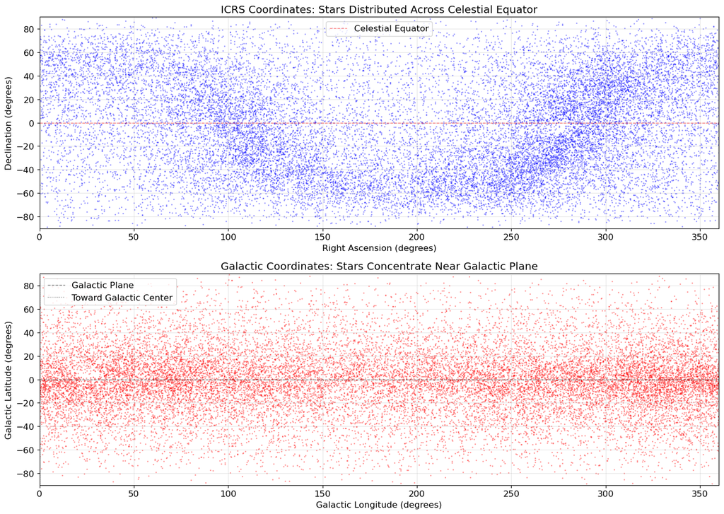

```python
# Transform to Galactic coordinates
allsky_coords_gal = allsky_coords.galactic

# Create comparison plot
fig, axes = plt.subplots(2, 1, figsize=(14, 10))

# Top: ICRS (RA/Dec)
axes[0].scatter(allsky_coords.ra.deg, allsky_coords.dec.deg, s=1, alpha=0.3, c='blue')
axes[0].set_xlabel('Right Ascension (degrees)')
axes[0].set_ylabel('Declination (degrees)')
axes[0].set_title('ICRS Coordinates: Stars Distributed Across Celestial Equator')
axes[0].set_xlim(0, 360)
axes[0].set_ylim(-90, 90)
axes[0].grid(alpha=0.3)
axes[0].axhline(0, color='red', linestyle='--', linewidth=1, alpha=0.5, label='Celestial Equator')
axes[0].legend()

# Bottom: Galactic
axes[1].scatter(allsky_coords_gal.l.deg, allsky_coords_gal.b.deg, s=1, alpha=0.3, c='red')
axes[1].set_xlabel('Galactic Longitude (degrees)')
axes[1].set_ylabel('Galactic Latitude (degrees)')
axes[1].set_title('Galactic Coordinates: Stars Concentrate Near Galactic Plane')
axes[1].set_xlim(0, 360)
axes[1].set_ylim(-90, 90)
axes[1].grid(alpha=0.3)
axes[1].axhline(0, color='black', linestyle='--', linewidth=1, alpha=0.5, label='Galactic Plane')
axes[1].axvline(0, color='black', linestyle=':', linewidth=1, alpha=0.5, label='Toward Galactic Center')
axes[1].legend()

plt.tight_layout()
plt.show()
```

**What do we see?**

In the top panel (ICRS coordinates), stars are distributed somewhat evenly across different declinations, with the distribution shaped by Earth's view from our position in the Galaxy. The celestial equator (red dashed line at `dec=0`) is just a projection of Earth's equator onto the sky - it has no physical significance to the stars themselves.

In the bottom panel (Galactic coordinates), the same stars cluster dramatically near the Galactic plane (black dashed line at `b=0`). This reveals the Milky Way's disk structure - most stars in our Galaxy orbit in a flat disk, so when we look in Galactic coordinates, we see this concentration immediately. The Galactic center direction (vertical dotted line at `l=0`) shows another concentration. Stars away from the plane (high `|b|`) are either nearby stars above/below the disk or more distant halo stars.

This illustrates why different coordinate systems matter. ICRS is good for catalog work and comparing observations across time. Galactic coordinates reveal the physical structure of our Galaxy. The choice depends on your science question.

### Angular Separation: Distance on the Sky

How far apart are two objects on the sky? We can't use simple Euclidean distance because the sky is a sphere. Use the `.separation()` method to calculate great circle distance (the shortest path along the sphere's surface).

```python
# Take two stars from our sample
star1 = coords[0]
star2 = coords[1]

# Calculate angular separation
sep = star1.separation(star2)

print(f"Star 1: RA={star1.ra:.4f}, Dec={star1.dec:.4f}")
print(f"Star 2: RA={star2.ra:.4f}, Dec={star2.dec:.4f}")
print(f"\nAngular separation: {sep}")
print(f"In arcminutes: {sep.to(u.arcmin):.2f}")
print(f"In arcseconds: {sep.to(u.arcsec):.1f}")
```

```
Star 1: RA=132.1046 deg, Dec=2.2711 deg
Star 2: RA=251.0976 deg, Dec=-56.9601 deg

Angular separation: 107.2944582600979 deg
In arcminutes: 6437.67 arcmin
In arcseconds: 386260.0 arcsec
```

**Why is this useful?**

The `.separation()` method computes the angular distance using spherical trigonometry (the haversine formula), accounting for the curvature of the sky. Simple RA/Dec differences would be wrong, especially near the poles where RA lines converge.

You can:

- Check if two catalog entries might be the same object (small separation suggests they're the same star observed in different surveys)
- Find objects within a certain angular distance of a target for field-of-view planning
- Cross-match catalogs by position (next section)
- Verify coordinate transformations (separation should be preserved)

## Cross-Matching by Position

### The Problem: Matching Catalogs Spatially

In Lecture 12, you learned to merge Pandas DataFrames using `pd.merge()` - matching rows where a common column like `source_id` is identical. This works great when both catalogs use the same identification system.

But what if the catalogs don't share a common ID? Different surveys assign different identifiers to the same objects. Gaia uses `source_id` numbers, 2MASS has its own designation system, SDSS uses yet another system. How do you match them?

The answer is to match by position. If two catalog entries have nearly identical coordinates on the sky, they're probably the same object. This is called cross-matching or positional matching, and it's essential for multi-wavelength astronomy where you combine observations from different telescopes and surveys.

### Example: Simulated Survey Data

Let's create a simulated "ground-based photometry survey" that observed some of our Gaia stars. The survey has its own IDs and slightly different positions due to measurement errors.

The simulation:

- Uses `np.random.choice()` to randomly select 200 stars from our Gaia sample
- Adds random position errors with `np.random.normal(0, 0.0003, n_obs)` which creates Gaussian noise with mean 0 and standard deviation 0.0003 degrees (~1 arcsecond)
- Creates survey-specific metadata (IDs, fluxes, dates)

```python
# Simulate a ground-based survey observing some of our stars
np.random.seed(42)
n_obs = 200
observed_indices = np.random.choice(len(gaia), n_obs, replace=False)

survey = pd.DataFrame({
    'survey_id': range(1, n_obs+1),  # Survey's own ID system
    'ra_survey': gaia['ra'].values[observed_indices] + np.random.normal(0, 0.0003, n_obs),  # ~1 arcsec errors
    'dec_survey': gaia['dec'].values[observed_indices] + np.random.normal(0, 0.0003, n_obs),
    'measured_flux': np.random.uniform(100, 10000, n_obs),
    'survey_date': pd.date_range('2024-01-01', periods=n_obs, freq='1D')
})

print(f"Created survey catalog with {len(survey)} observations")
print("\nFirst few entries:")
survey.head()
```

```
Created survey catalog with 200 observations

First few entries:
```

|  | survey_id | ra_survey | dec_survey | measured_flux | survey_date |
| --- | --- | --- | --- | --- | --- |
| 0 | 1 | 241.755 | -1.624 | 6699.509 | 2024-01-01 |
| 1 | 2 | 231.924 | -67.117 | 1283.664 | 2024-01-02 |
| 2 | 3 | 56.614 | -29.338 | 5769.164 | 2024-01-03 |
| 3 | 4 | 212.967 | 4.389 | 2641.761 | 2024-01-04 |
| 4 | 5 | 117.078 | 51.831 | 8060.547 | 2024-01-05 |

**The challenge:**

- The survey has its own IDs (1, 2, 3, ...) that don't correspond to Gaia's `source_id` values
- Survey positions (`ra_survey`, `dec_survey`) differ slightly from Gaia due to measurement errors (we've added random errors of about 1 arcsecond, typical for ground-based astrometry)
- We have no common ID column to use `pd.merge()`

How do we match survey objects to our Gaia catalog?

### Creating SkyCoords for Both Catalogs

First, convert both catalogs to `SkyCoord` objects. We already have `coords` for our Gaia catalog. Now create coordinates for the survey data.

```python
# Gaia coordinates (already have these)
coords_gaia = coords

# Survey coordinates
coords_survey = SkyCoord(
    ra=survey['ra_survey'].values*u.deg,
    dec=survey['dec_survey'].values*u.deg,
    frame='icrs'
)

print(f"Gaia catalog: {len(coords_gaia)} stars")
print(f"Survey catalog: {len(coords_survey)} observations")
print("\nNow we need to match them...")
```

```
Gaia catalog: 5000 stars
Survey catalog: 200 observations

Now we need to match them...
```

### Cross-Matching: Finding Nearest Neighbors

The `.match_to_catalog_sky()` method finds the nearest match in a reference catalog for each object.

It returns three arrays:

- `idx`: The index of the best match in the reference catalog (here: Gaia) for each query object (here: survey)
- `sep`: Angular separation between each query and its match (as a `Quantity` with angular units)
- `dist3d`: 3D distance between objects if both catalogs have distance information (will be None if one or both SkyCoords don't have distances)

The method call `coords_survey.match_to_catalog_sky(coords_gaia)` means: "For each survey position, find the closest Gaia star."

```python
# Match survey coordinates to Gaia catalog
idx, sep, dist3d = coords_survey.match_to_catalog_sky(coords_gaia)

print(f"Matched {len(idx)} survey objects")
print(f"\nFirst 5 matches:")
print(f"Survey object → Gaia index: {idx[:5]}")
print(f"Separations: {sep[:5].to(u.arcsec)}")
```

```
Matched 200 survey objects

First 5 matches:
Survey object → Gaia index: [1501 2586 2653 1055  705]
Separations: [2.08059323 1.43610102 0.42563521 1.85941193 0.91054248] arcsec
```

**What happened?**

For each of the 200 survey observations, Astropy found the closest Gaia star:

- The `idx` array tells us which Gaia star matched each survey object. For example, `idx[0]` contains the Gaia catalog index that's closest to survey object 0.
- The `sep` array tells us how far apart they are, typically about 1 arcsecond due to the measurement errors we simulated
- The `dist3d` is None because our survey coordinates don't have distance information - we'd need distances for both catalogs to compute 3D separations

This gives us a way to link the two catalogs even though they use different ID systems.

### Filtering Good Matches

Not all matches are real! If the separation is large, it might be a random nearby star rather than the actual counterpart. We need a **matching radius** - the maximum separation we'll accept as a real match.

Typical choices:

- For Gaia-level precision (~1 milliarcsecond): use 1 arcsecond matching radius
- For older ground-based catalogs (~1 arcsecond precision): use 2-5 arcseconds
- Too small: miss real matches
- Too large: get false matches from random nearby stars

The matching radius should be roughly 3-5 times your typical position uncertainty.

```python
# Set matching radius
match_radius = 3.5 * u.arcsec

# Find good matches (within radius)
good_matches = sep < match_radius

print(f"Total survey objects: {len(survey)}")
print(f"Good matches (< {match_radius}): {good_matches.sum()}")
print(f"No match (> {match_radius}): {(~good_matches).sum()}")
print(f"\nMatch rate: {100*good_matches.sum()/len(survey):.1f}%")
```

```
Total survey objects: 200
Good matches (< 3.5 arcsec): 200
No match (> 3.5 arcsec): 0

Match rate: 100.0%
```

We matched all survey objects to Gaia! The comparison `sep < match_radius` creates a boolean array where `True` means the separation is acceptable. We then use `.sum()` to count how many `True` values exist (Python treats `True` as 1 and `False` as 0 in arithmetic).

### Creating the Merged Catalog

Now we can create a merged DataFrame combining Gaia and survey data, similar to `pd.merge()` but based on position matching rather than ID matching.

The process:

1. Filter survey to only good matches: `survey[good_matches]`
2. Select corresponding Gaia rows using the match indices: `gaia.iloc[idx[good_matches]]`
3. Reset indices and add temporary merge column to both DataFrames
4. Combine with `pd.merge()` on the temporary column
5. Add match quality metric (separation)

```python
# Create merged catalog (only good matches)
survey_matched = survey[good_matches].copy()
gaia_matched = gaia.iloc[idx[good_matches]].reset_index(drop=True)

# Combine into one DataFrame using merge
# Add a temporary index column to both DataFrames for merging
survey_matched_temp = survey_matched.reset_index(drop=True)
survey_matched_temp['_merge_idx'] = range(len(survey_matched_temp))

gaia_matched_temp = gaia_matched.reset_index(drop=True)
gaia_matched_temp['_merge_idx'] = range(len(gaia_matched_temp))

merged = pd.merge(
    survey_matched_temp,
    gaia_matched_temp[['_merge_idx', 'source_id', 'parallax', 'pmra', 'pmdec', 'radial_velocity', 'phot_g_mean_mag']],
    on='_merge_idx'
).drop('_merge_idx', axis=1)

# Add separation as quality metric
merged['match_separation_arcsec'] = sep[good_matches].to(u.arcsec).value

print(f"Merged catalog: {len(merged)} objects")
print("\nSample entries:")
merged[['survey_id', 'source_id', 'measured_flux', 'phot_g_mean_mag', 'match_separation_arcsec']].head()
```

```
Merged catalog: 200 objects

Sample entries:
```

|  | survey_id | source_id | measured_flux | phot_g_mean_mag | match_separation_arcsec |
| --- | --- | --- | --- | --- | --- |
| 0 | 1 | 4406320787078848000 | 6699.509 | 14.650 | 2.081 |
| 1 | 2 | 5823627932840427520 | 1283.664 | 12.580 | 1.436 |
| 2 | 3 | 5080104261356834304 | 5769.164 | 5.894 | 0.426 |
| 3 | 4 | 3671143882034910592 | 2641.761 | 14.595 | 1.859 |
| 4 | 5 | 984110396313838464 | 8060.547 | 11.963 | 0.911 |

**Success!** We've combined:

- Survey's flux measurements and observation dates
- Gaia's positions, proper motions, and photometry
- A quality metric showing the match separation

### Visualizing Match Quality

Let's examine the distribution of match separations to verify our matches are good.

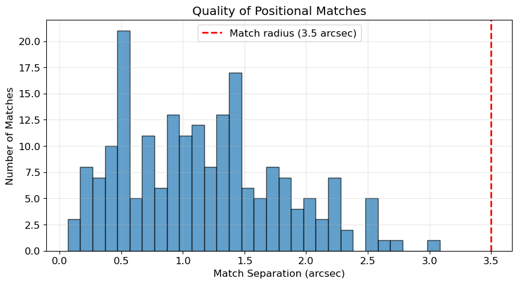

```
Median separation: 1.103 arcsec
Mean separation: 1.163 arcsec
Max separation: 3.084 arcsec
```

```python
# Plot separation distribution
plt.figure(figsize=(10, 5))

plt.hist(merged['match_separation_arcsec'], bins=30, edgecolor='black', alpha=0.7)
plt.axvline(match_radius.to(u.arcsec).value, color='red', linestyle='--',
            linewidth=2, label=f'Match radius ({match_radius})')
plt.xlabel('Match Separation (arcsec)')
plt.ylabel('Number of Matches')
plt.title('Quality of Positional Matches')
plt.legend()
plt.grid(alpha=0.3)
plt.show()

print(f"Median separation: {merged['match_separation_arcsec'].median():.3f} arcsec")
print(f"Mean separation: {merged['match_separation_arcsec'].mean():.3f} arcsec")
print(f"Max separation: {merged['match_separation_arcsec'].max():.3f} arcsec")
```

### Real-World Applications

Cross-matching is used constantly in astronomy:

**Multi-wavelength studies**: Match optical observations from SDSS with infrared from 2MASS, X-ray from Chandra, and radio from VLA. Each wavelength reveals different physics - optical shows stellar photospheres, infrared penetrates dust, X-rays reveal high-energy processes, and radio traces cold gas and magnetic fields.

**Time-domain astronomy**: Match transient detections across multiple epochs to identify variable stars, supernovae, and AGN by tracking how sources change over time.

**Survey validation**: Compare new surveys to established catalogs to check for systematic errors in positions or photometry.

**Spectroscopic follow-up**: Match photometric targets to spectroscopic observations to combine imaging and chemical composition data.

Your observation log from Lecture 12 could be matched to Gaia this way if you recorded coordinates but didn't include Gaia `source_id`s!

## 6D Phase Space: 3D Positions and Velocities

### Why Can We Do This with Gaia?

Gaia provides us with **complete 6D phase space information** for many stars:

- **3D Position**: RA, Dec, and parallax (which gives distance)
- **3D Velocity**: Proper motions (pmra, pmdec) and radial velocity

This complete phase space information allows us to compute both:

1. **3D Cartesian positions (X, Y, Z)** - where stars are in 3D space
2. **3D Galactic velocities (U, V, W)** - how stars are moving in 3D space

However, not all catalogs provide all these measurements:

- Many catalogs only have sky positions (RA, Dec) without distances
- Some have positions but no proper motions
- Radial velocities require spectroscopy and are harder to obtain

**This is why cross-matching is essential**: By combining Gaia's complete astrometry (positions, distances, proper motions, radial velocities) with other surveys' photometry, spectroscopy, or specialized measurements, we can build complete pictures of astronomical objects. Gaia gives us the full 6D phase space - other surveys give us additional physical properties.

Now let's see how to use this 6D information to compute both positions and velocities in Galactic coordinates.

### 3D Cartesian Positions: Where Stars Are

First, let's create a SkyCoord object with all the 6D phase space information from our Gaia data. This will allow us to compute both positions and velocities in various coordinate systems.

```python
# Create SkyCoord with complete 6D phase space information
# This includes position (RA, Dec, distance) and velocity (proper motions, radial velocity)

coords_6d = SkyCoord(
    ra=gaia['ra'].values * u.deg,
    dec=gaia['dec'].values * u.deg,
    distance=distance_q,  # From parallax
    pm_ra_cosdec=pmra_q,  # Proper motion in RA (already corrected by cos(dec))
    pm_dec=pmdec_q,       # Proper motion in Dec
    radial_velocity=gaia['radial_velocity'].values * u.km/u.s,  # Radial velocity
    frame='icrs'
)

print(f"Created SkyCoord with 6D phase space for {len(coords_6d)} stars")
print(f"\nFirst star's 6D information:")
print(f"  Position (RA, Dec): ({coords_6d[0].ra:.4f}, {coords_6d[0].dec:.4f})")
print(f"  Distance: {coords_6d[0].distance:.2f}")
print(f"  Proper motion: pmra={coords_6d[0].pm_ra_cosdec:.3f}, pmdec={coords_6d[0].pm_dec:.3f}")
print(f"  Radial velocity: {coords_6d[0].radial_velocity:.2f}")
```

```
Created SkyCoord with 6D phase space for 5000 stars

First star's 6D information:
  Position (RA, Dec): (132.1046 deg, 2.2711 deg)
  Distance: 79.37 pc
  Proper motion: pmra=4.014 mas / yr, pmdec=66.102 mas / yr
  Radial velocity: 35.98 km / s
```

```python
# Get 3D Cartesian coordinates (Sun-centered, Galactic frame)
# When we transform to Galactic and get Cartesian coordinates,
# the origin is at the Sun's position
coords_cartesian = coords_6d.galactic.cartesian

print(f"First star's Cartesian position (Sun-centered):")
print(f"X (toward Galactic center): {coords_cartesian.x[0]:.2f}")
print(f"Y (Galactic rotation direction): {coords_cartesian.y[0]:.2f}")
print(f"Z (toward North Galactic Pole): {coords_cartesian.z[0]:.2f}")

# Calculate 3D distance from Sun
distance_3d = np.sqrt(coords_cartesian.x**2 + coords_cartesian.y**2 + coords_cartesian.z**2)
print(f"\n3D distance from Sun: {distance_3d[0]:.2f}")
print(f"Compare to direct distance: {coords_6d[0].distance:.2f}")
print("These should match (they do!)")
```

```
First star's Cartesian position (Sun-centered):
X (toward Galactic center): -50.00 pc
Y (Galactic rotation direction): -50.10 pc
Z (toward North Galactic Pole): 35.92 pc

3D distance from Sun: 79.37 pc
Compare to direct distance: 79.37 pc
These should match (they do!)
```

The `.cartesian` attribute converts spherical coordinates (RA/Dec/distance or l/b/distance) to Cartesian (x, y, z) using standard transformations. The 3D distance calculated from Cartesian coordinates matches the original distance, confirming the transformation is correct.

**Important:** In the Galactic Cartesian system:

- The **origin is at the Sun** (our observing position)
- **X-axis** points from the Sun toward the Galactic center
- **Y-axis** points in the direction of Galactic rotation (90° from center in the Galactic plane)
- **Z-axis** points toward the North Galactic Pole

These Cartesian positions are useful for:

- Computing actual 3D separations (not just angular)
- Finding nearest neighbors in 3D space
- Identifying clusters and substructure
- Calculating gravitational potentials

### Visualizing 3D Distribution

Let's plot our stars in 3D Galactic coordinates to see their true spatial distribution. We'll use matplotlib's 3D plotting capabilities.

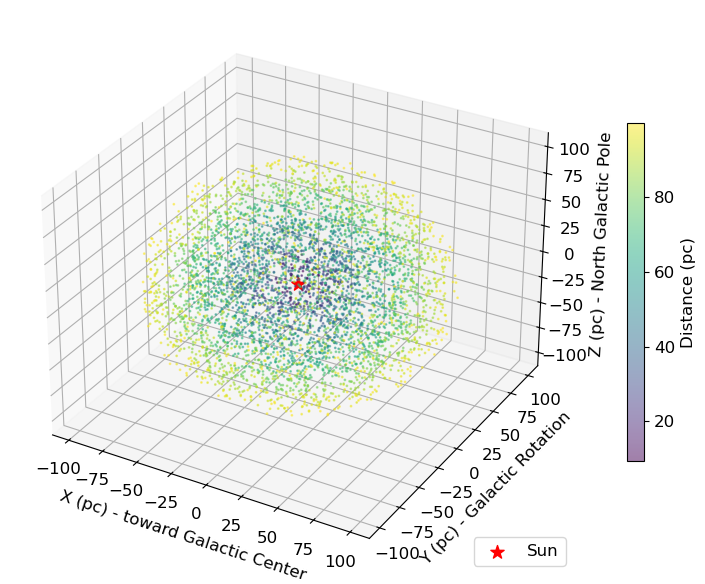

```python
# Create 3D scatter plot
from mpl_toolkits.mplot3d import Axes3D

fig = plt.figure(figsize=(11, 6))
ax = fig.add_subplot(111, projection='3d')

# Extract X, Y, Z coordinates
X = coords_cartesian.x.to(u.parsec).value
Y = coords_cartesian.y.to(u.parsec).value
Z = coords_cartesian.z.to(u.parsec).value

# Color by distance
distances = coords.distance.to(u.parsec).value
scatter = ax.scatter(X, Y, Z, c=distances, s=1, alpha=0.5, cmap='viridis')

# Mark the Sun's position
ax.scatter([0], [0], [0], c='red', s=100, marker='*', label='Sun')

ax.set_xlabel('X (pc) - toward Galactic Center', labelpad=5)
ax.set_ylabel('Y (pc) - Galactic Rotation', labelpad=5)
ax.set_zlabel('Z (pc) - North Galactic Pole', labelpad=5)
ax.legend(loc='lower right')

plt.colorbar(scatter, ax=ax, label='Distance (pc)', shrink=0.6)
plt.tight_layout()
plt.show()
```

We see a sphere of stars centered on the Sun (red star). The color gradient shows distance - yellow/green stars are farther away than blue/purple ones.

The plot uses `.to(u.parsec).value` to:

1. Convert the `Quantity` to parsecs (in case it's in different units)
2. Extract just the numerical value for matplotlib (which doesn't understand `Quantity` objects)

This 3D view reveals the true spatial distribution that's completely hidden when we only look at 2D sky positions. Two stars that appear close together on the sky might be at very different distances and therefore not physically associated.

### 3D Galactic Velocity Components: U, V, W

Now that we can see where stars are in 3D space, let's examine how they're moving. Using the same `coords_6d` object, we can directly compute the 3D velocity components in Galactic coordinates.

These velocities reveal different stellar populations:

- **U**: Velocity toward the Galactic center (positive = toward center)
- **V**: Velocity in the direction of Galactic rotation (positive = direction of rotation)
- **W**: Velocity toward the North Galactic Pole (positive = toward pole)

All velocities are measured relative to the Sun (the Local Standard of Rest would require additional corrections).

```python
# Now use our coords_6d to get Galactic velocity components
# Transform to Galactic frame (coords_6d already has all velocity info)
gal_coords = coords_6d.galactic

# Get Galactic velocity components U, V, W
# These are automatically calculated from the proper motions and radial velocity
U = gal_coords.velocity.d_x.to(u.km/u.s)  # Velocity toward Galactic center
V = gal_coords.velocity.d_y.to(u.km/u.s)  # Velocity in direction of Galactic rotation
W = gal_coords.velocity.d_z.to(u.km/u.s)  # Velocity toward North Galactic Pole

print(f"First star's Galactic velocity components:")
print(f"  U: {U[0]:.2f}")
print(f"  V: {V[0]:.2f}")
print(f"  W: {W[0]:.2f}")

# Add to DataFrame for later analysis
gaia['U_km_s'] = U.value
gaia['V_km_s'] = V.value
gaia['W_km_s'] = W.value

print(f"\nGalactic velocity statistics:")
print(gaia[['U_km_s', 'V_km_s', 'W_km_s']].describe())
```

```
First star's Galactic velocity components:
  U: -33.14 km / s
  V: -3.60 km / s
  W: 28.36 km / s

Galactic velocity statistics:
         U_km_s    V_km_s    W_km_s
count  5000.000  5000.000  5000.000
mean     -8.985   -22.338    -8.137
std      38.206    28.005    19.850
min    -200.130  -323.974  -123.736
25%     -31.703   -33.447   -17.712
50%     -10.315   -18.531    -7.474
75%      12.963    -5.131     2.015
max     279.616    67.723   101.615
```

The `SkyCoord` with velocity information:

- `pm_ra_cosdec`: Proper motion in RA already multiplied by cos(dec). Gaia provides this directly because RA lines converge at the poles.
- `pm_dec`: Proper motion in Dec
- `radial_velocity`: Line-of-sight velocity

The `.galactic` transformation rotates the coordinate frame to Galactic coordinates. The `.velocity` attribute accesses the velocity information, and `.d_x`, `.d_y`, `.d_z` give the Cartesian velocity components (derivatives of position) in the Galactic frame.

Finally, `.to(u.km/u.s)` converts to standard astronomical velocity units.

### Interpreting Galactic Velocities: Toomre Diagram

Let's visualize the velocity distribution in the U-V plane. This is called a Toomre diagram and reveals stellar populations. The circles we'll draw represent constant total velocity magnitudes in the U-V plane.

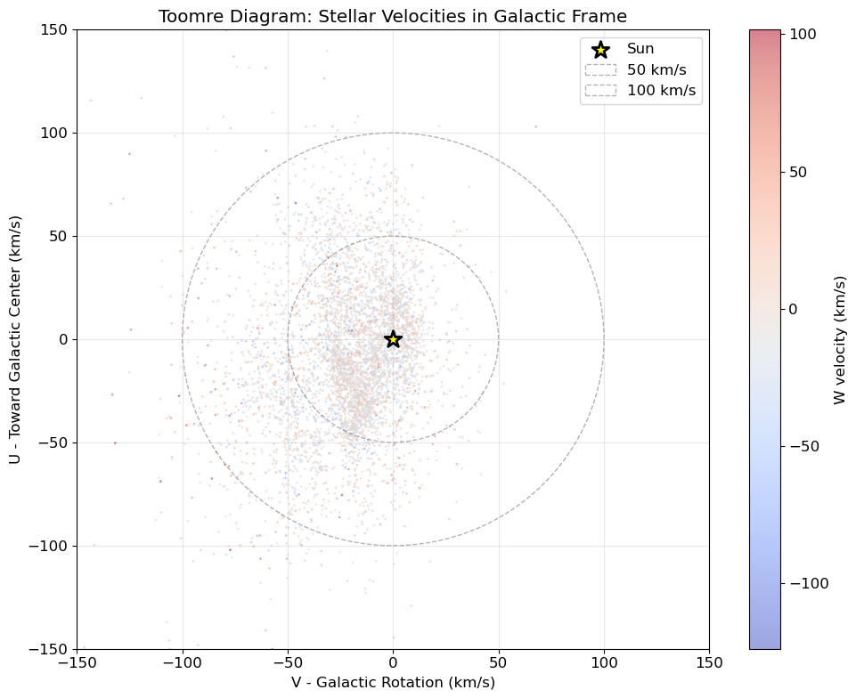

```python
# Create Toomre diagram (U vs V)
plt.figure(figsize=(10, 8))

# Filter to stars with good velocities
good_rv = gaia['radial_velocity'].notna()

plt.scatter(gaia.loc[good_rv, 'V_km_s'], gaia.loc[good_rv, 'U_km_s'],
            s=1, alpha=0.5, c=gaia.loc[good_rv, 'W_km_s'], cmap='coolwarm')
plt.colorbar(label='W velocity (km/s)')

# Mark the Sun (at rest in this frame)
plt.scatter([0], [0], c='yellow', s=200, marker='*', edgecolor='black',
            linewidth=2, label='Sun', zorder=10)

# Draw circles showing typical velocity dispersions
circle1 = plt.Circle((0, 0), 50, fill=False, linestyle='--',
                     color='black', alpha=0.3, label='50 km/s')
circle2 = plt.Circle((0, 0), 100, fill=False, linestyle='--',
                     color='black', alpha=0.3, label='100 km/s')
plt.gca().add_patch(circle1)
plt.gca().add_patch(circle2)

plt.xlabel('V - Galactic Rotation (km/s)')
plt.ylabel('U - Toward Galactic Center (km/s)')
plt.title('Toomre Diagram: Stellar Velocities in Galactic Frame')
plt.legend()
plt.grid(alpha=0.3)
plt.xlim(-150, 150)
plt.ylim(-150, 150)
plt.tight_layout()
plt.show()
```

**What does this show?**

Most stars cluster near the Sun (yellow star at origin) with velocities less than 50 km/s. These are typical thin disk stars with kinematics similar to the Sun.

The scatter increases with distance from center. Older stellar populations have higher velocity dispersions because they've been gravitationally stirred over billions of years.

Objects far from the origin (greater than 100 km/s) might belong to the thick disk or halo - different Galactic components with different formation histories.

The color shows W-velocity (motion perpendicular to the Galactic plane). Stars with high vertical velocities (`|W|` > 50 km/s, appearing red or blue) often trace old-disk or non-disk populations. This plot reveals stellar populations - groups of stars with similar ages and formation histories that can be identified by their kinematics even without knowing their chemical composition or ages!

## Summary

### What You Can Now Do

After working through this material, you should be able to:

- Query Gaia, Simbad, and other archives for stars in any sky region with custom selection criteria
- Perform calculations with physical units that automatically convert and prevent errors
- Transform coordinates between ICRS, Galactic, and Ecliptic systems
- Cross-match catalogs by position to combine observations from different surveys
- Compute 3D positions and velocities from astrometric measurements
- Create Toomre diagrams to identify stellar populations by kinematics

### Practice Suggestions

To solidify these concepts:

1. Query a different sky region by picking your favorite constellation and retrieving bright stars from Gaia
2. Calculate Earth's orbital velocity using `v = sqrt(GM/R)` with Astropy units
3. Display 10 stars' positions in ICRS, Galactic, and Ecliptic coordinates
4. Query both Gaia and 2MASS near the same target and cross-match by position
5. Identify the highest velocity star in your sample
6. Query stars near a known cluster (M67 or Hyades) and compute their velocity dispersion

### Looking Ahead

Next, you'll learn about astronomical time systems and observation planning. Lecture 14 introduces time standards (UTC, TAI, TDB), observation planning tools (visibility, airmass, twilight), AltAz coordinates for telescope pointing, and FITS files (astronomy's native format). These tools build on your coordinate and query skills - you'll plan real observations and work with astronomical images!